# Snowflakes or Tough Cookies?

How citizens judge harassment against politicians  
DIPAS Workshop 2025

**Søren Damsbo-Svendsen**

Karina Kosiara-Pedersen

September 23, 2025

## Motivation

- There is both loose **conjecture** (e.g., political debate) and careful **theory** about *heterogeneous perceptions of harassment among citizens*
- But little **solid empirical evidence**
  - ‘solid’: large/broad *data collection* and broad *‘harassment’ concept*
- **RQ: *How severe is harassment* against politicians to citizens, and what are theoretically and statistically significant *gaps in perceptions* of harassment?**
  - i.e., are (harassed) politicians perceived as *snowflakes* or *tough cookies*? By whom?
- Preregistered **survey:**
  - large sample (n = 8,899) from **4 European countries**
  - 55 **true stories** of (Danish) politicians’ experiences with harassment
  - **outcome**: perceived severity
  - 43,460 judgments of a diverse set of harassment stories

## Status

- First draft
- Data part of larger project with experiment
- **Analysis** quite broad/deep and quite far
  - main results ‘final’
  - possibly need for **cuts**, possibility for **extensions**
  - **gender and age** weaved into every analysis for coherence
- Framing and especially **theory** quite underdeveloped
  - we’d love to hear some of your takes on our findings

## Design

- New multinational preregistered **survey**
- **n = 8,899 respondents**
  - Denmark: n = 5,008 (YouGov)
  - Germany: n = 1,519 (Prolific)
  - United Kingdom: n = 1,515
  - France: n = 857
- **Harassment stories**
  - respondents read and evaluate **5 harassment stories**
  - real stories about (Danish) politicians’ experiences with harassment
  - source: Danish 2021 municipal election candidate survey (n = 3,986)
  - *stimulus sampling* design with random draw from **55 curated stories**

## Examples of harassment stories

> “I have experienced my election posters being ‘decapitated’ by unknown persons. My children, aged seven and nine, have seen this, which was very unpleasant.”

> “I have experienced unpleasant advances in private messages on social media from people of all ages.”

> “I have received death threats from unknown senders directed at both my little brothers and my own children.”

> “There was a citizen who drove around in a car and measured how high my - and only my - posters were placed from the ground. He then reported me to the police for banners that were placed too low.”

## How the stories are presented and judged

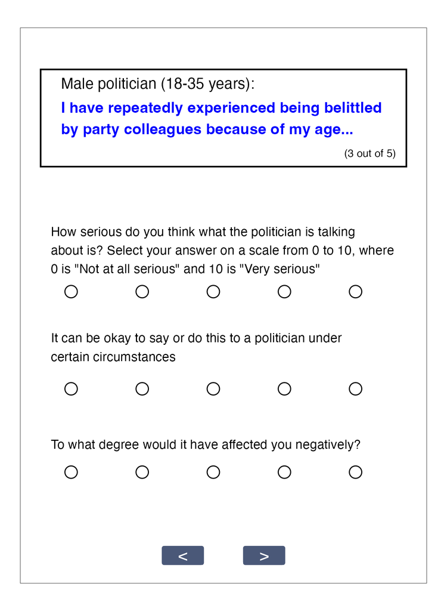

- 1 of 4 **politician** *gender-age* categories (randomized)
- Story
- **Judgment** on three dimensions: *seriousness*, *justifiableness*, *harmfulness*

Repeats five times

## Perceived severity

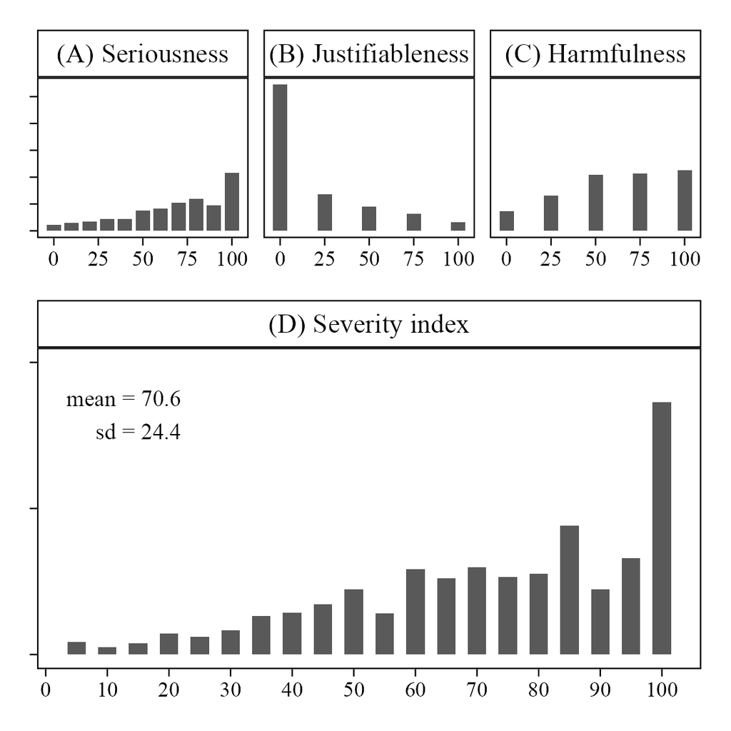

- Judgments are combined into a **severity index**
- I.e., respondents de facto rate each story’s severity from 0 to 100
- => 43,460 judgments of 55 harassment stories
- **Analytic focus:** theoretically and statistically significant **gaps in perceived severity** by key explanatory variables
  - a.k.a. *predictors*, *covariates*
  - e.g., gender, ideology, risk perception
  - **four ‘themes’** →

## Explanatory variables – four themes

- **A Gender and age**
  1. gender
  2. age
  3. gender-age
  4. politicians’ gender-age
  5. gender-age affinity
- **B Ideology**
  6. left-right placement (general)
  7. harassment attitudes (specific)
- **C Risk and likely candidates**
  8. harassment risk perception
  9. general conflict aversion
  10. likely candidate (predicted)
  11. likely candidate (expressed ambition)
- **D Harassment type**
  12. physical harassment, violence (threats), vandalism (non-person)
  13. sexual harassment
  14. social media (arena)
  15. system-insider (source)

# Results: A Gender and age

## Gender gap in perceived severity?

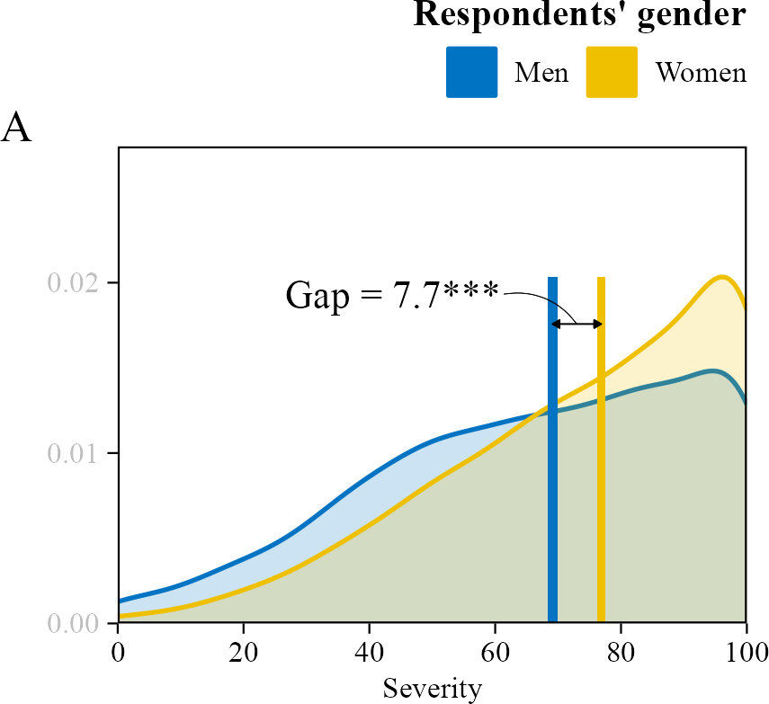

## A Gender and age

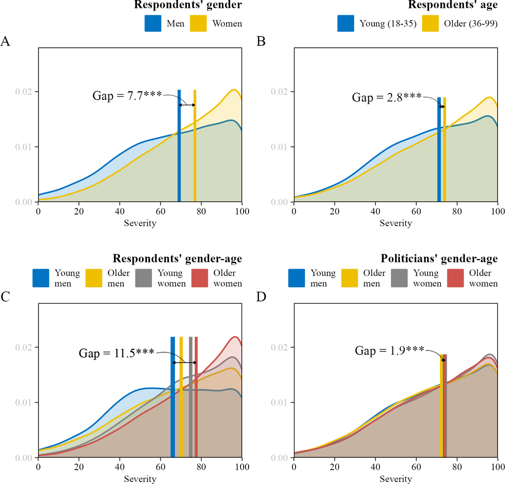

- A: Higher severity for **women**
- B: Lower severity for **young**
- C: Highest severity for **older women**, lowest for young men
- D: Highest severity when **politician** (target) is **young woman**, lowest when older man

## A Gender-age affinity

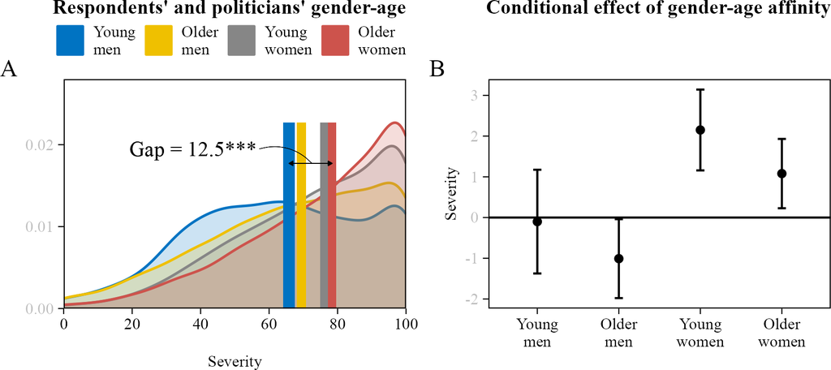

- A: Subset to stories with **gender-age affinity** (~25%)
- A: Gaps similar to full sample
- B: Gender-age affinity causes higher severity for **women**
- B: Gender-age affinity causes lower severity for **older men**
- B: Largely driven by perceptions related to **politician’s identity**

# Results: B Ideology

## B Ideology

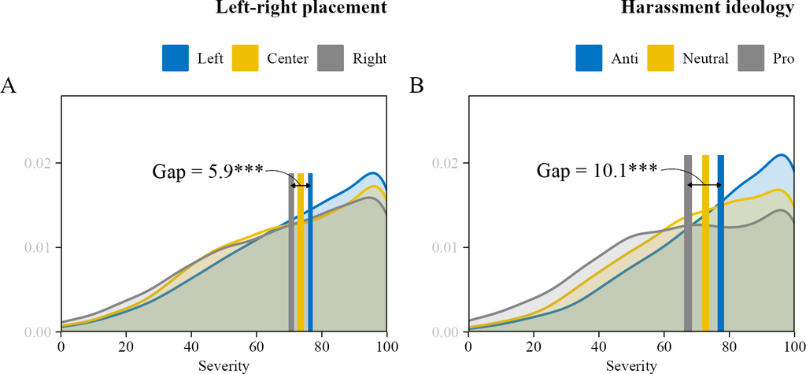

- A: Higher severity for **left-leaning** respondents
- B: Higher severity for respondents with clear **anti-harassment** attitudes
- → Specific harassment-related ideology more important than general ideological leaning
- Ideological gaps ~2-4 %-points smaller for women

# Results: C Risk and likely candidates

## C Risk and likely candidates

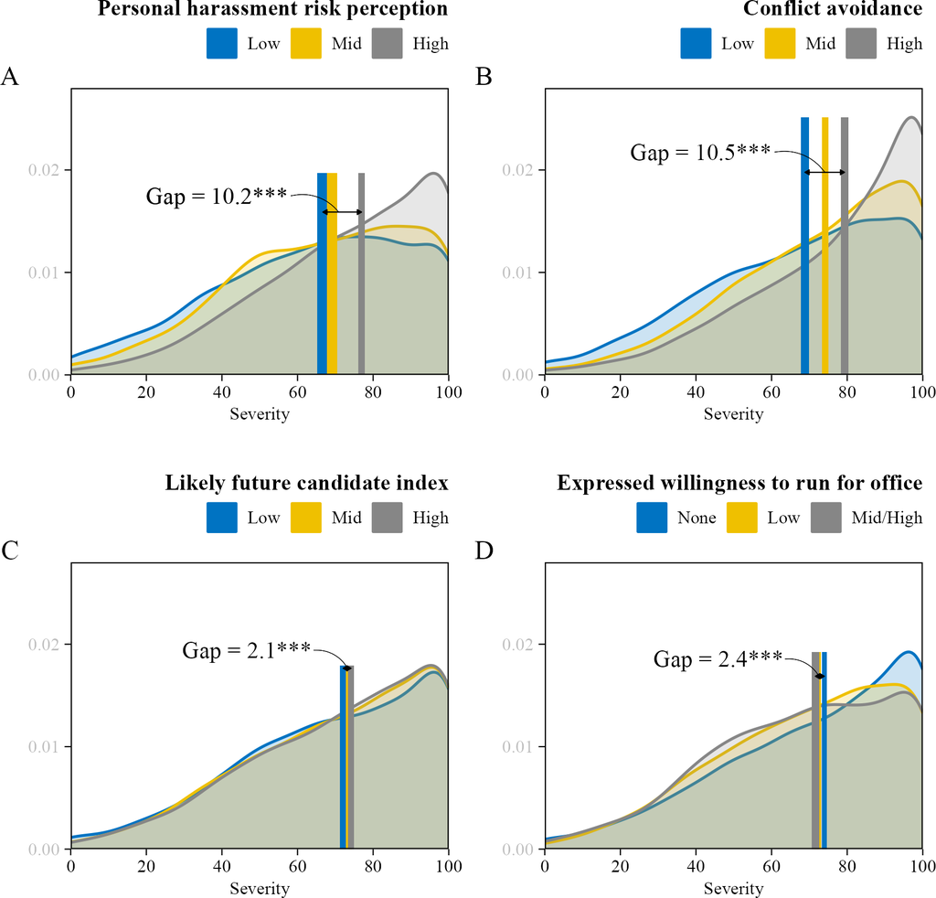

- A: Higher severity for respondents with high **risk perceptions**
- B: Higher severity for respondents with high **conflict avoidance**
- C: Higher severity for **likely future candidates** (index),  
  but …
- D: Lower severity for citizens with **expressed political ambition** (??)

## C Risk and likely candidates

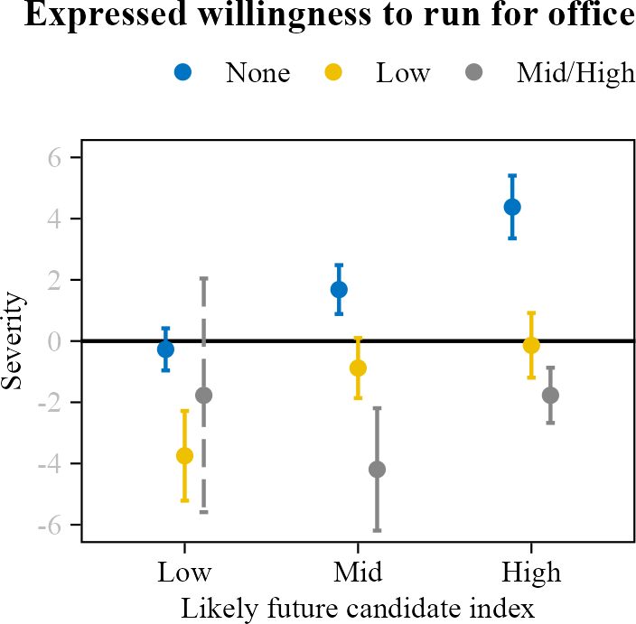

## C Risk and likely candidates

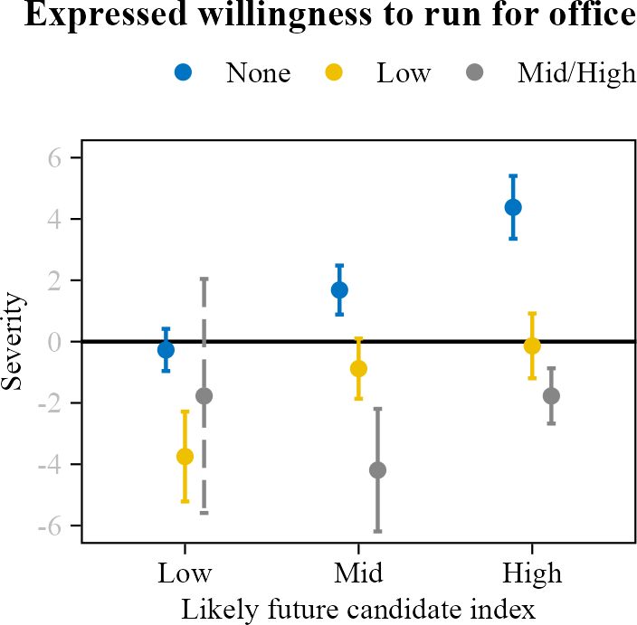

- **Plausible interpretation**:
  - those who actively consider politics (*expressed ambition*) have factored harassment in, devalued the severity, are less surprised
  - or, due to self-selection, they have ‘thicker skin’ to begin with
- **Raises questions**:
  - about who’s willing to run/stay
  - about whether/when/how candidates’ perceptions of harassment change

# Results: D Harassment type

## D Harassment type

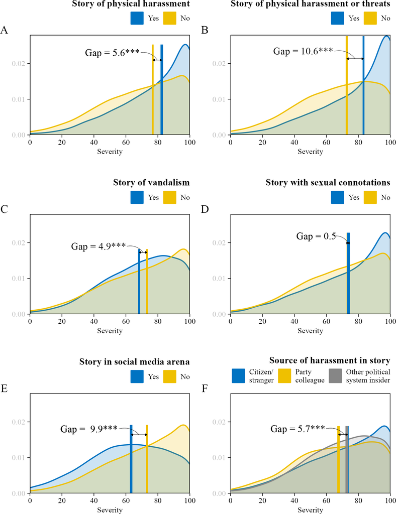

- A-B: higher severity for stories of **physical harassment** and (threats of) violence
- C: Lower severity for stories of **vandalism** (i.e., higher when target is a person)
- D: No gap for **sexual** vs. non-sexual harassment
- D: But large positive gap for **young** and small negative gap for older people

## D Harassment type

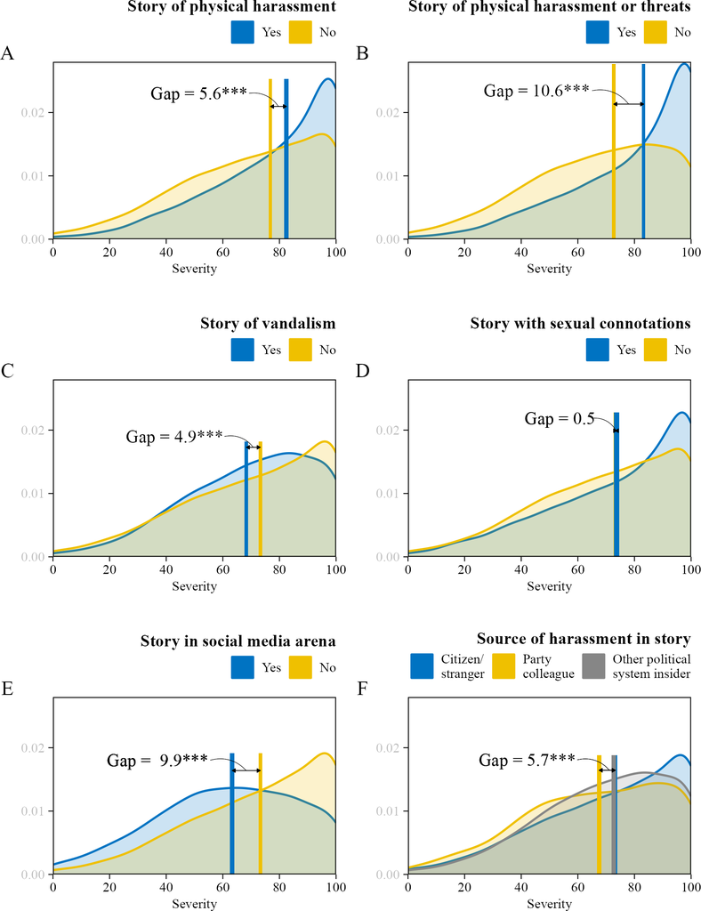

- E: Lower severity for stories in **social media** arena
- E: Especially among **young people** (gap smaller among women)
- F: Lower severity when **party colleague** is ‘source’  
  (more excusable?)
- F: Gap smaller among women

## To do: theory/interpretation/discussion

- *Why* do we find these gaps? How do we *explain* them? What are their *causes*?
- What are the*implications*?
- How (much) do we *discuss*?
- Best *framing*?
- Paper *structure* (four ‘themes’ etc.)? Need to throw out parts or parcel into another paper?

# Conclusions

- We asked **how citizens perceive harassment** against politicians in terms of *severity*
- Focus on important gaps within **four distinct themes:**
  - A Gender and age
  - B Ideology
  - C Risk and likely candidates
  - D Harassment type
- Find numerous **important and interesting gaps**
  - some **expected** (e.g., gender, ideology, risk and conflict aversion, physical)
  - others **unexpected** (e.g., age, gender-age affinity, sexual, party colleague)
  - also interesting **gender/age gaps** *in other gaps* (e.g., woman x ideology, age x sexual)
- Causal effects of the stories in separate paper